# Data Visualization

# Diabetes Data Description

Scenario: You are a health analytics consultant that has been asked to perform an exploratory data analysis regarding diabetes. You are given a dataset containing information for 100 randomly sampled patients from all patients at a specific hospital. The dataset includes the following:

- **Gender**: Their gender (Male or Female)
- **Diabetes_Type**: Their type of diabetes
- **Age**: Their age (in *whole* years, no decimals)
- **Smoking_Status**: Their smoking status (current, former, or never)
- **Number_of_Visits**: The number of times they’ve visited the hospital
- **Exercise_Frequency**: How often they exercise
- **Fasting_Blood_Sugar**: Their blood sugar level while fasting (mg/dL)
- **HbA1c**: Glucose attached to hemoglobin in red blood cells (mmol/mol)

```r
suppressWarnings(suppressMessages(library(ggplot2)))
suppressWarnings(suppressMessages(library(dplyr)))

diabetes_data <- read.csv("../Datasets/diabetes_data.csv") # Fill in the path to the dataset
attach(diabetes_data)
```

Complete the questions below by filling in the blanks with the appropriate answers or by providing the necessary R code.

## Question 1 (4 points)

Below is a histogram of Fasting_Blood_Sugar.

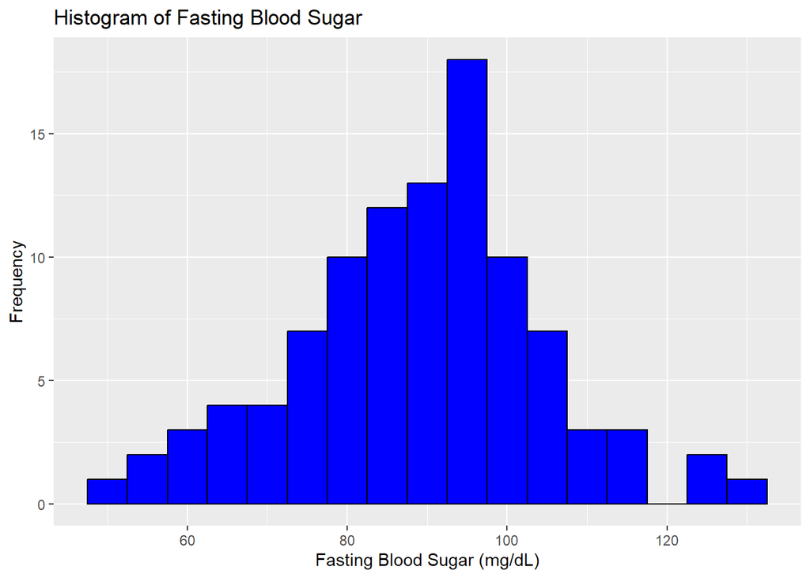

```r
ggplot(diabetes_data, aes(x = Fasting_Blood_Sugar)) +
  geom_histogram(binwidth = 5, fill = "blue", color = "black") +
  labs(title = "Histogram of Fasting Blood Sugar",
       x = "Fasting Blood Sugar (mg/dL)",
       y = "Frequency")
```

Using this histogram, what would you say is the skewness of the distribution? This distribution is mostly symmetric. You could also possibly say there is a *very slight* left-skew. Most people would say it is symmetric, but both of these answers could be considered correct.

Based on the skew, would you expect the mean to be less than, greater than, or approximately equal to the median? If you say that the distribution looks symmetric, then you would expect the mean and median to be very close to one another. If you believe there is a very slight left skew, then you would say that the mean is less than the median.

Compute and display the mean and median for Fasting_Blood_Sugar below.

```r
mean(Fasting_Blood_Sugar)
```

```
[1] 88.954
```

```r
median(Fasting_Blood_Sugar)
```

```
[1] 90.25
```

The two are very close to one another because of the symmetry of the distribution. The mean is slightly less than the median indicating that there is a *slight* left skew.

## Question 2 (1 point)

Below is a histogram of Number_of_Visits.

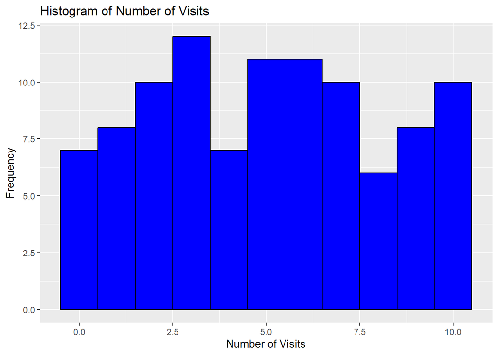

```r
ggplot(diabetes_data, aes(x = Number_of_Visits)) +
  geom_histogram(binwidth = 1, fill = "blue", color = "black") +
  labs(title = "Histogram of Number of Visits",
       x = "Number of Visits",
       y = "Frequency")
```

Based on the histogram, would you say the distribution is unimodal, bimodal, or multimodal? This distribution is multimodal. There appear to be three major peaks.

## Question 3 (4 points)

Which visualizations would be appropriate for the following variables? Just provide one answer for each of the following.

- Smoking_Status: Bar chart (could also say Pie Chart)
- Fasting_Blood_Sugar: 100 observations is somewhere between small and medium in terms of size, so any of the following could be used: Histogram, Box Plot, Dot Chart, or Stem-and-Leaf Plot
- Diabetes_Type: Bar chart (could also say Pie Chart)
- Number_of_Visits: 100 observations is somewhere between small and medium in terms of size, so any of the following could be used: Histogram, Box Plot, Dot Chart, or Stem-and-Leaf Plot

## Question 4 (2 points)

Produce a visualization for the following variables:

### HbA1c

The dataset has 100 observations, which is somewhere between a small and medium sized dataset. Any of the following charts would work alright.

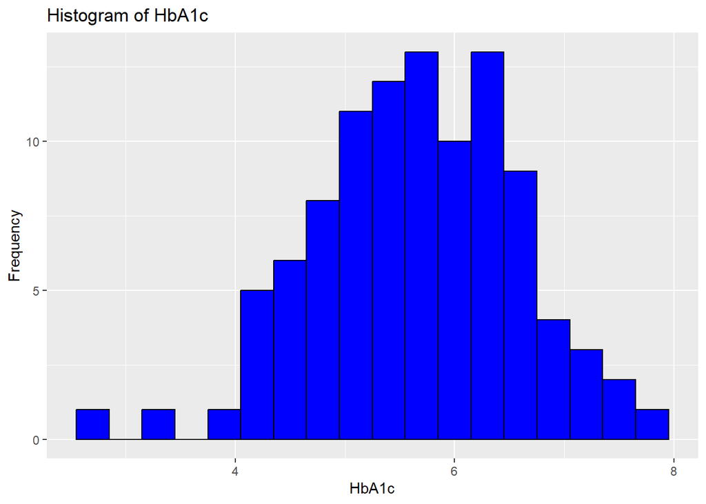

```r
diabetes_data %>% ggplot(aes(x = HbA1c)) +
  geom_histogram(binwidth = 0.3, fill = "blue", color = "black") +
  labs(title = "Histogram of HbA1c") +
  ylab("Frequency")
```

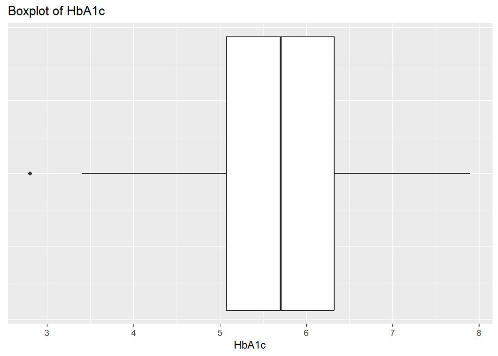

```r
diabetes_data %>% ggplot(aes(x = HbA1c)) +
  geom_boxplot() +
  labs(title = "Boxplot of HbA1c") +
  theme(axis.title.y = element_blank(),
        axis.text.y = element_blank(),
        axis.ticks.y = element_blank())
```

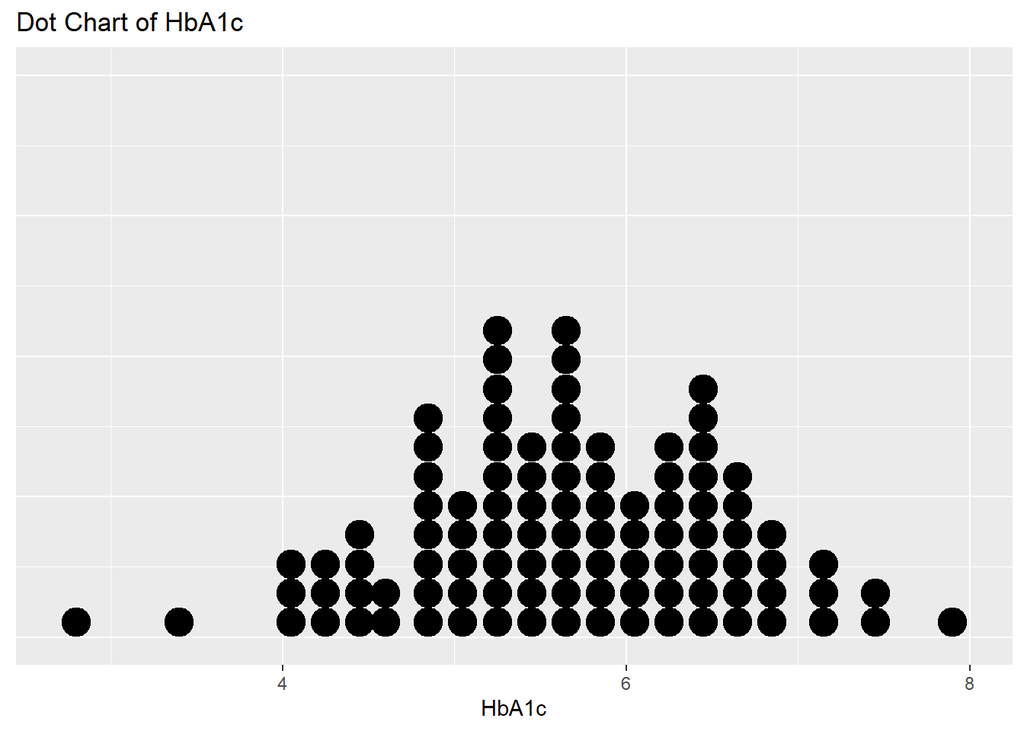

```r
diabetes_data %>% ggplot(aes(x = HbA1c)) +
  geom_dotplot() +
  labs(title = "Dot Chart of HbA1c") +
  theme(axis.title.y = element_blank(),
      axis.text.y = element_blank(),
      axis.ticks.y = element_blank())
```

```r
stem(HbA1c, scale = 2)
```

```
  The decimal point is at the |

  2 | 8
  3 | 4
  3 |
  4 | 01123344
  4 | 556688999999
  5 | 0001122222233333444444
  5 | 5666677777778899999
  6 | 011112222333444444
  6 | 5556667778899
  7 | 1224
  7 | 59
```

### Exercise_Frequency

Either a bar chart of a pie chart could be used, although it is recommended that one use a bar chart.

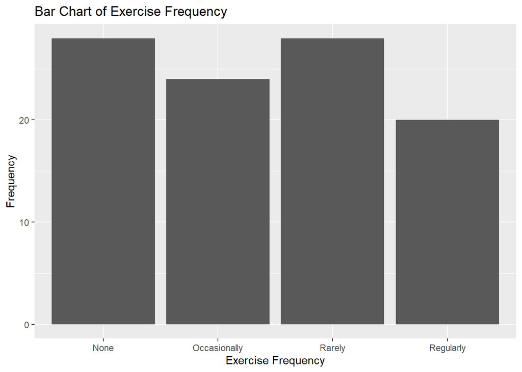

```r
diabetes_data %>% ggplot(aes(x = Exercise_Frequency)) +
  geom_bar() +
  xlab("Exercise Frequency") +
  labs(title = "Bar Chart of Exercise Frequency") +
  ylab("Frequency")
```

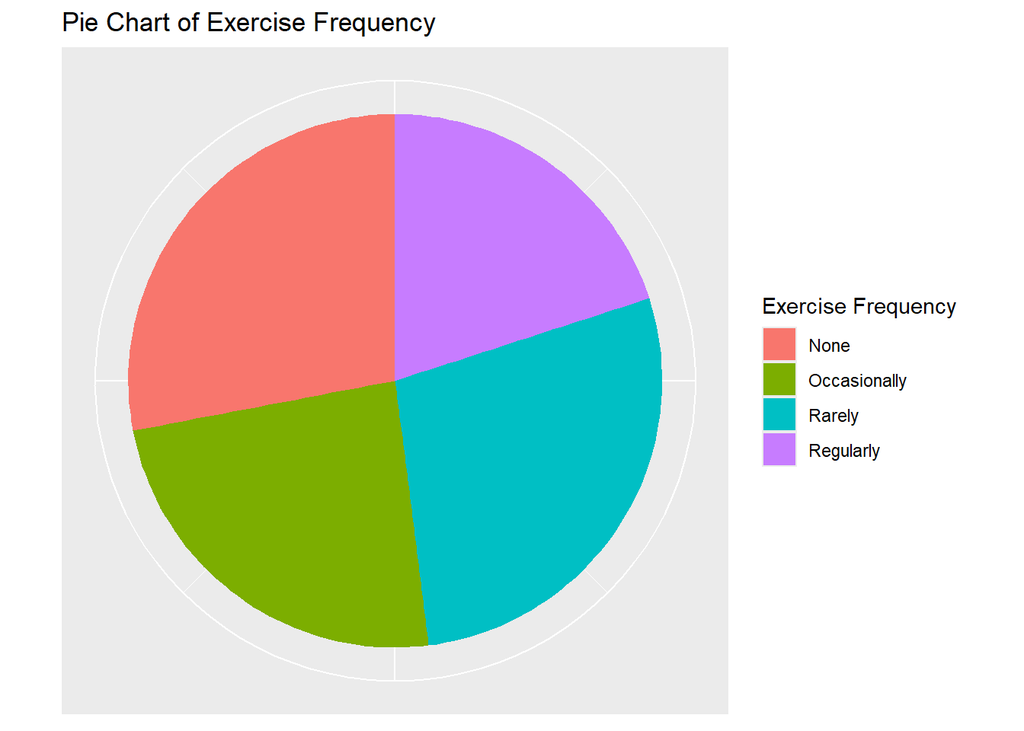

```r
diabetes_data %>% ggplot(aes(x = factor(1), fill = factor(Exercise_Frequency))) +
  geom_bar(width = 1) + coord_polar(theta = "y") +
  labs(title = "Pie Chart of Exercise Frequency") +
  theme(axis.title.y = element_blank(),
      axis.text.y = element_blank(),
      axis.ticks.y = element_blank(),
      axis.title.x = element_blank(),
      axis.text.x = element_blank(),
      axis.ticks.x = element_blank()) +
  scale_fill_discrete(name = "Exercise Frequency")
```